# Course Project 1

Pozhitkova

### Reproducible Research Course Project 1

```r
pacman::p_load(plyr, dplyr, tidyr)
pacman::p_load(readr, haven, ggplot2)
select<-dplyr::select
```

## Loading and preprocessing the data

Load the data

```r
setwd("C:/!KRISTINA/!COURSERA/R_Reproducible Research/Course Project 1")
if(!file.exists('activity.csv')){
    unzip('activity.zip')
}
df <- read.csv('activity.csv')
```

## What is mean total number of steps taken per day?

1. Calculate the total number of steps taken per day

```r
steps_day <- df %>% group_by(date) %>%
        summarise(total_steps_by_day=sum(steps, na.rm=TRUE))
```

2. Make a histogram of the total number of steps taken each day

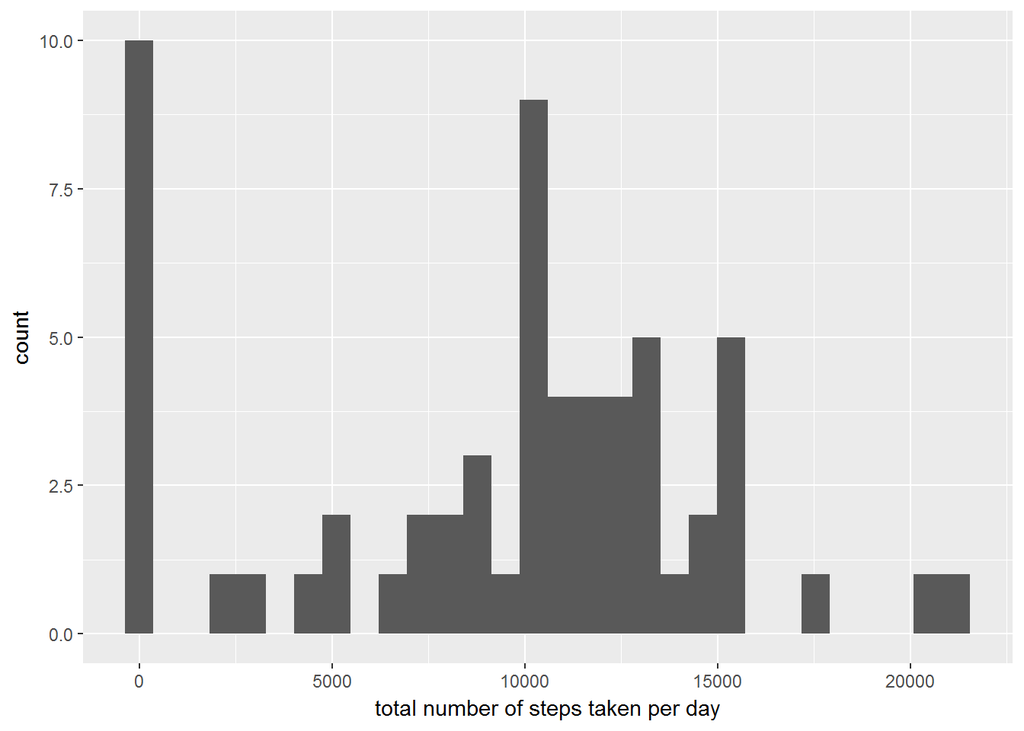

```r
ggplot(steps_day,  aes(total_steps_by_day)) + geom_histogram() + xlab("total number of steps taken per day")
```

3. Calculate and report the mean and median of the total number of steps taken per day

```r
mean_steps <- round(mean(steps_day$total_steps_by_day),1)
median_steps <- median(steps_day$total_steps_by_day)
```

The mean = 9354.2 and median = 10395 of the total number of steps taken per day.

## What is the average daily activity pattern?

1. Time series plot of the 5-minute interval and the average number of steps taken, averaged across all days

```r
steps_interval <- df %>% group_by(interval) %>%
        summarise(mean_steps_interval=mean(steps, na.rm=TRUE))
```

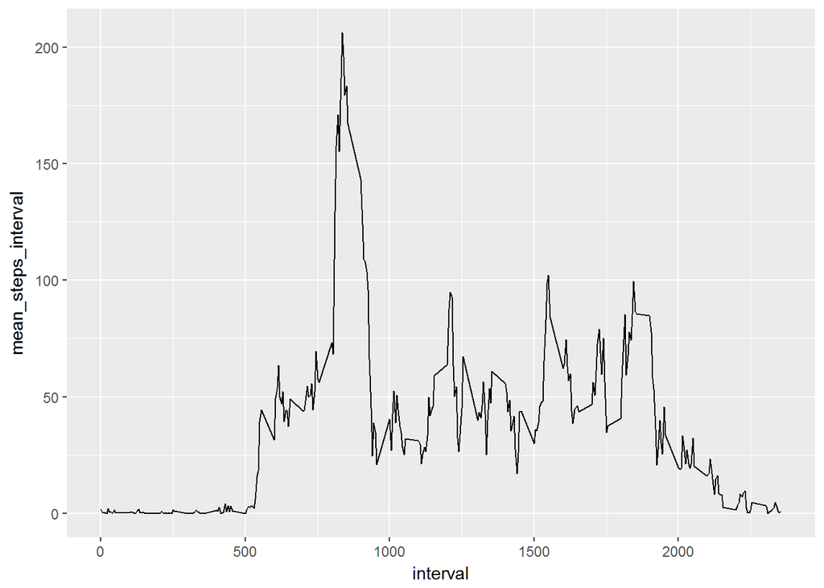

```r
ggplot(data=steps_interval, aes(x=interval, y=mean_steps_interval)) + geom_line()
```

2. Which 5-minute interval, on average across all the days in the dataset, contains the maximum number of steps?

```r
interval_max_steps<-(steps_interval%>%arrange(desc(mean_steps_interval)))$interval[1]
```

The maximum number of steps in interval = 835

## Imputing missing values

1. Calculate and report the total number of missing values in the dataset

```r
countNA<-dim(df%>%filter(is.na(steps)))[1]
```

The total number of missing values in the dataset 2304.

3. Create a new dataset that is equal to the original dataset but with the missing data filled in.

```r
df_imp <- df%>% group_by(interval) %>%
        mutate_at(vars(steps) , funs(ifelse(is.na(.),mean(.,na.rm=TRUE), .)))
```

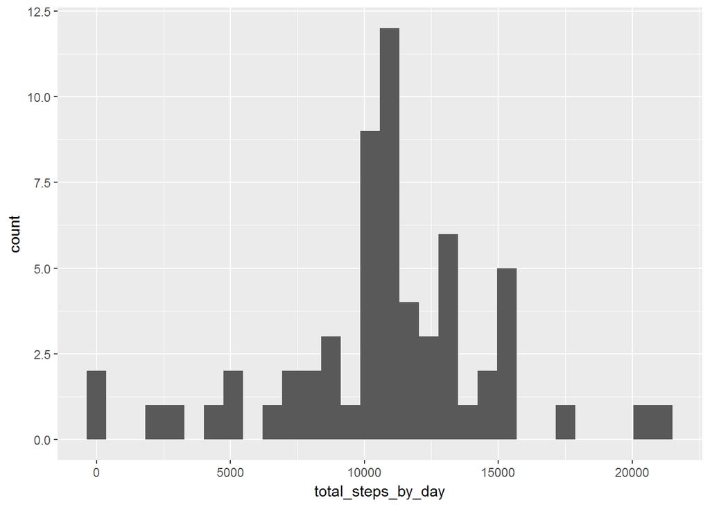

```r
steps_day_imp <- df_imp %>% group_by(date) %>%
        summarise(total_steps_by_day=sum(steps, na.rm=TRUE))

ggplot(steps_day_imp,  aes(total_steps_by_day)) +   geom_histogram()
```

```r
mean_steps_imp <- round(mean(steps_day_imp$total_steps_by_day),1)
median_steps_imp <- median(steps_day_imp$total_steps_by_day)
```

## Are there differences in activity patterns between weekdays and weekends?

1. Create a new factor variable in the dataset with two levels – “weekday” and “weekend” indicating whether a given date is a weekday or weekend day.

```r
df_imp_type<-df_imp%>% mutate(type = weekdays(as.POSIXlt(date)))  %>%
        mutate(type=ifelse(type=="суббота"|type=="воскресенье",'weekend', 'weekday'))%>%
        group_by(type, interval)%>%summarise(mean_steps_interval=mean(steps, na.rm=TRUE))
```

2. Make a panel plot containing a time series plot

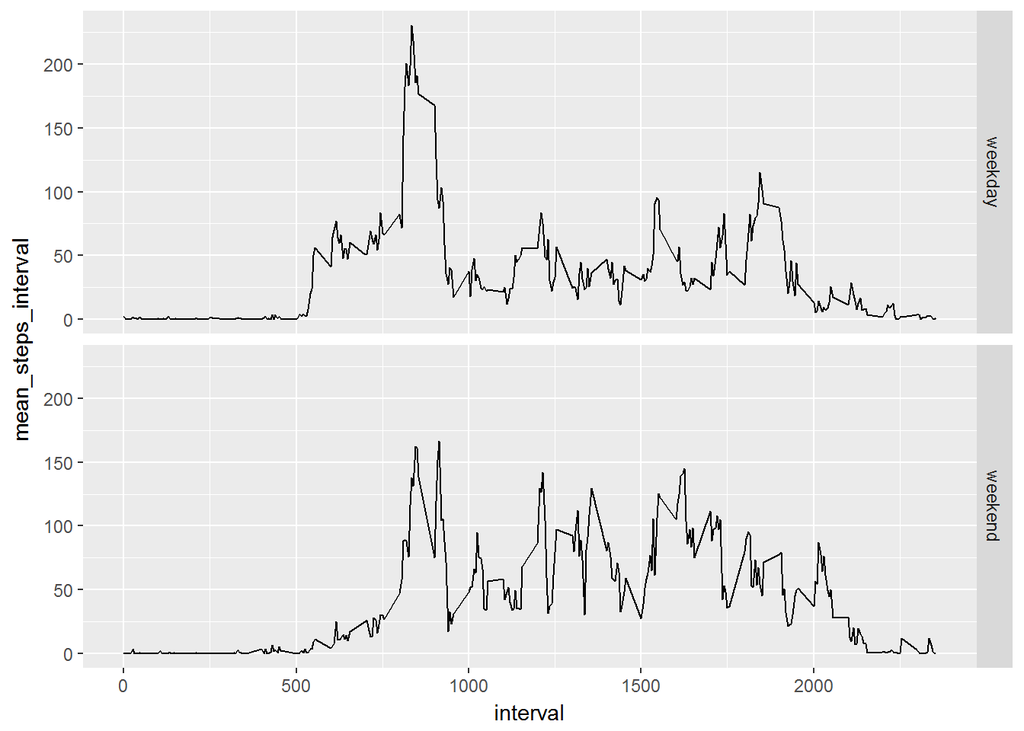

```r
ggplot(data=df_imp_type, aes(x=interval, y=mean_steps_interval)) + geom_line() +facet_grid(type ~ .)
```